# 202512_morph_lm

```r
library("geomorph")
library("dplyr")
options(rgl.useNULL=TRUE)
library("rgl")
library("tidyverse")
library("gtools")
library(lubridate)
library(gridExtra)
library(factoextra)
```

```r
library(ggplot2)
library(clustvarsel)
library(mclust)
library(ggpubr)
library(svglite)
```

# Import data file

**need to set working dir here**

```r
df <- readRDS("/Volumes/Yinghui/202512-dev-seq-analyses/data/20C-202509-dev-seq-v5.rds")
```

```r
# convert the lm to matrix for each file.

specs_list <- df %>%
  group_by(temp, biorep,ind, plane, file) %>%
  group_map(~ {
    id <- paste(.y$temp,.y$biorep, .y$ind, .y$plane, .y$file, sep = "_")

    # Create a sub-list for this specific identifier
    spec <- list(
      matrix = as.matrix(.x[, c("X", "Y")]),
      metadata = as.list(.y)
    )

    setNames(list(spec), id)
  }) %>%
  flatten()
```

Temporary issue

```r
# 1. missing 1 landmark

t <- c(4607.161391, 2099.636741)
specs_list[["20_202509-dev-seq_11_TA_1007-TA-2.csv"]][["matrix"]] <- rbind(specs_list[["20_202509-dev-seq_11_TA_1007-TA-2.csv"]][["matrix"]], t)

rownames(specs_list[["20_202509-dev-seq_11_TA_1007-TA-2.csv"]][["matrix"]]) <- NULL

# 2. 1 csv has . instead of - between plane and date
specs_list[["20_202509-dev-seq_2_OA_1011.OA-1X.csv"]][["metadata"]][["file"]] <- "1011-OA-1X.csv"
```

```r
# add lm 10 in the TA plane
specs_list<-add_lm10(specs_list)
```

# Plot setting

```r
palette1 <- c("#343434","#A3CEF1","#3880ba","#224f73","#000000","#CCCAC2","#837D72","#ede7da")
```

#linear measurements

```r
measurement_accumulator <- list()

for (id in names(specs_list)) {

  # 1. Extract components correctly
  spec   <- specs_list[[id]]
  mat    <- spec$matrix
  plane  <- spec$metadata$plane
  ind    <- spec$metadata$ind
  temp <- spec$metadata$temp
  biorep <- spec$metadata$biorep
  file <- spec$metadata$file

  # 2. Initialize a placeholder for this specific iteration's results
  res <- tibble()

  # 3. Apply custom "Design" logic
  if (plane == "PA") {
    res <- tibble(
      measure_name = c("ALO", "AW", "WAE", "ATCL"),
      value = c(ALO_fun(mat), AW_fun(mat), WAE_fun(mat), ATCL_fun(mat))
    )

  } else if (plane == "TA") {
    res <- tibble(
      measure_name = c("PL", "BL", "TCL", "LTM", "LL", "TABW"),
      value = c(PL_fun(mat), BL_fun(mat), TCL_fun(mat), LTM_fun(mat), LL_fun(mat), TABW_fun(mat))
    )

  } else if (plane == "OA") {
    res <- tibble(
      measure_name = c("TBL", "PW", "ATAC", "AEAC"),
      value = c(TBL_fun(mat), PW_fun(mat), ATAC_fun(mat), AEAC_fun(mat))
    )
  }

  # 4. Add metadata and store in accumulator
  # Only add if we actually generated results
  if (nrow(res) > 0) {
    measurement_accumulator[[id]] <- res %>%
      mutate(
        sample_id = str_remove(file, "-.*"),
        ind = ind,
        plane = plane,
        temp = temp,
        biorep = biorep
      )
  }
}

# 5. Bind into one large dataframe
df_lm <- bind_rows(measurement_accumulator)

df_lm <- df_lm %>% mutate(
    # Convert from microns (or current unit) to mm
    value = value / 1000
  )
```

Removing the value of lobate and auricle when those structures are not present

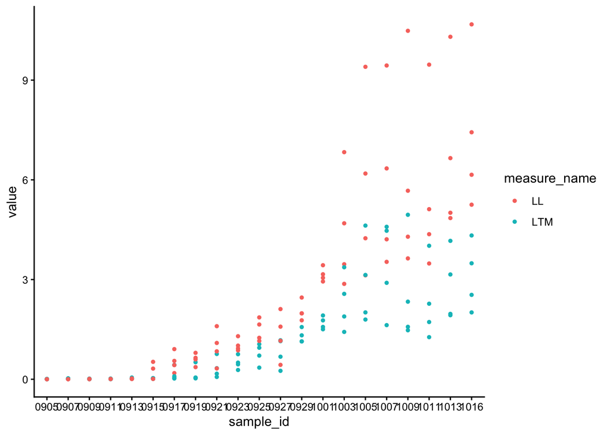

```r
df_onlyLA <- df_lm %>% group_by(measure_name) %>% filter(measure_name %in% c("LL", "LTM")) %>% ungroup()

ggplot(df_onlyLA,aes(x=sample_id, y = value, color = measure_name))+
  geom_point(size = 1) +
  theme_classic() +
  scale_fill_manual(values = palette1)
```

```r
df_lm <- df_lm  %>%
  mutate(
    value = case_when(
      sample_id %in% c("0905", "0907", "0909", "0911", "0913","0915") & measure_name %in% c("LL", "LTM","ALO", "AW") ~ NA,
      sample_id %in% c( "0917", "0919") &  measure_name %in% c("ALO", "AW") ~ NA,
      TRUE ~ value
    )
  )

#df_lm <- drop_na(df_lm)
```

## allometric dev visualisation

### obtain the natural log of the value

Common practice when studying allometric development because it is easier to deal with proportional variation.

```r
#create a new column with log value
df_lm <- df_lm %>% mutate(log_value = log(value))
```

### plot allometric dev

Using body length as the x axis

```r
df_BL <- df_lm %>%
  # 1. Create a lookup of just the BL values
  left_join(
    df_lm %>%
      filter(measure_name == "BL") %>%
      select(sample_id, ind, bl_value = value, bl_log = log_value),
    by = c("sample_id","ind")
  ) %>%
  filter(!(measure_name %in% c("BL")))
 # filter(!(measure_name %in% c("BL","PL","TABW")))
```

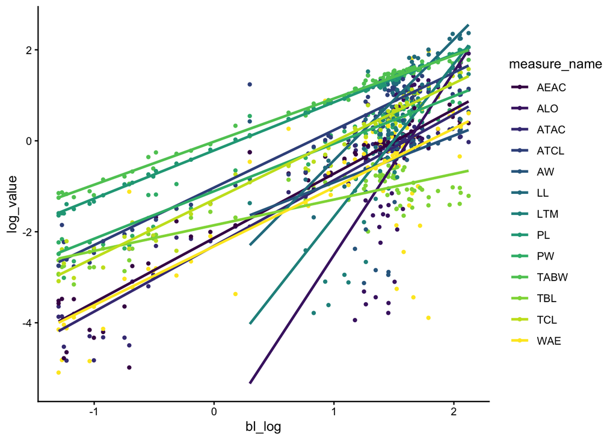

```r
p <- ggplot(df_BL, aes(x = bl_log, y = log_value, color = measure_name)) +
  geom_point(size = 1) +
  geom_smooth(method = "lm", se = FALSE, linewidth = 1) +
  theme_classic() +
   scale_color_viridis_d()+ scale_fill_hue(c = 70)

p
```

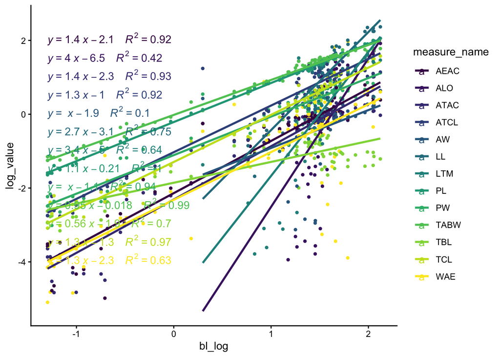

```r
ggsave("/Volumes/Yinghui/202512-dev-seq-analyses/fig/dev.svg", width=10, height=8)
p <- p + stat_regline_equation(aes(label =  paste(..eq.label.., ..rr.label.., sep = "~~~~")))
p
```

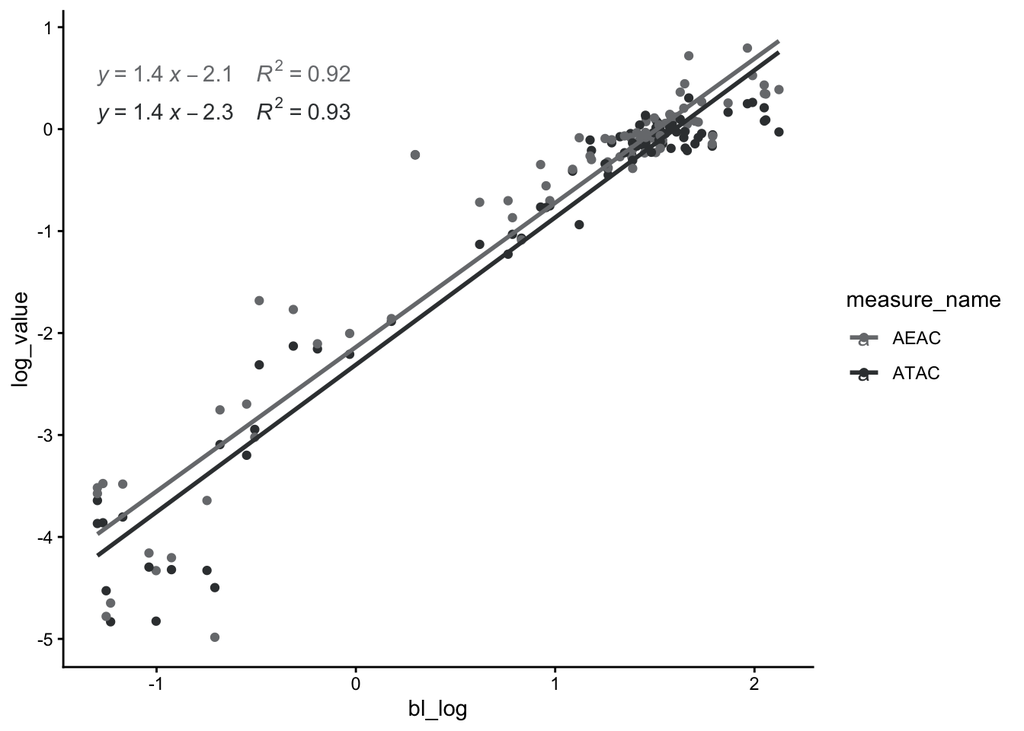

```r
measurement <- c("AEAC","ATAC")
oa <- df_BL %>%
  filter(measure_name %in% measurement) %>% # Only keeps these three
  ggplot(aes(x = bl_log, y = log_value, color = measure_name)) +
  geom_point() +
  geom_smooth(method = "lm", se = FALSE) +
  theme_classic() +scale_color_manual(values = c("AEAC" = "#787A7D", "ATAC" = "#393D3F"))+ stat_regline_equation(aes(label =  paste(..eq.label.., ..rr.label.., sep = "~~~~")))
oa
```

```r
measurement <- c("TABW","TCL","WAE","PW")
fig_total <- df_BL %>%
  filter(measure_name %in% measurement) %>% # Only keeps these three
  ggplot(aes(x = bl_log, y = log_value, color = measure_name)) +
  geom_point() +
  geom_smooth(method = "lm", se = FALSE) +
  theme_classic() +scale_color_manual(values = c("TABW" = "#546A7B", "TCL" = "#8FABB7", "WAE" = "#384F57", "PW" = "#8DB2F9"))+ stat_regline_equation(aes(label =  paste(..eq.label.., ..rr.label.., sep = "~~~~")))
```

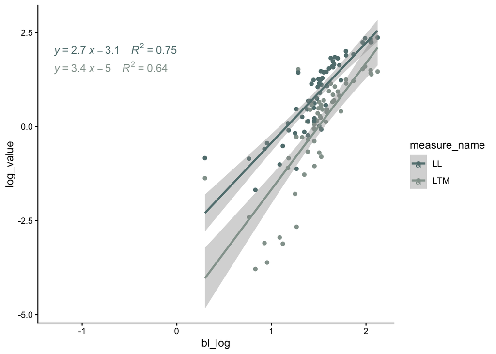

```r
measurement <- c("LL","LTM")
fig_lobe <- df_BL %>%
  filter(measure_name %in% measurement) %>% # Only keeps these three
  ggplot(aes(x = bl_log, y = log_value, color = measure_name)) +
  geom_point() +
  geom_smooth(method="lm") +
  theme_classic() +scale_color_manual(values = c("LL" = "#627F7F", "LTM" = "#94A29C"))+
stat_regline_equation(aes(label =  paste(..eq.label.., ..rr.label.., sep = "~~~~")))

fig_lobe
```

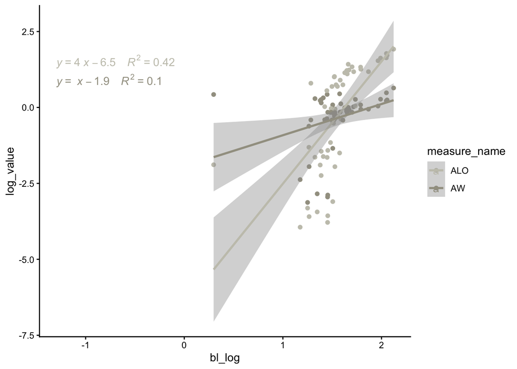

```r
measurement <- c("ALO","AW")
fig_auricle <- df_BL %>%
  filter(measure_name %in% measurement) %>% # Only keeps these three
  ggplot(aes(x = bl_log, y = log_value, color = measure_name)) +
  geom_point() +
  geom_smooth(method = "lm") +
  theme_classic() +scale_color_manual(values = c("ALO" = "#C6C5B9", "AW" = "#A29F90")) + stat_regline_equation(aes(label =  paste(..eq.label.., ..rr.label.., sep = "~~~~")))

#fig_total
fig_auricle
```

combine plots

```r
dev<-ggarrange(fig_total, oa, fig_auricle, fig_lobe, ncol = 2, nrow = 2)
ggsave(file="/Volumes/Yinghui/202512-dev-seq-analyses/fig/dev.svg", plot=dev)
```

## Standardization and then study allometric development

### Removing isometry through Calculate centroid through geometric mean

isometric component of shape (i.e., the shape that changes in a 1:1 proportion with size) is removed

To approximate this effect in the LMM context, we used an approach that is analogous to centroid size extraction by deriving the geometric mean of all variables of a specimen as the equivalent of that specimen’s centroid size and using log-shape ratios (log10[measurement/geometric mean]) as isometry-free shape variables. (Viacava 2023)

```r
df_lmw_nolog <- df_lm %>%
  select(-c(plane, log_value)) %>%
  group_by(sample_id, ind) %>%
  pivot_wider(
    names_from = measure_name,
    values_from = value
  )
```

```r
df_lmw <- df_lm %>%
  select(-c(plane, value)) %>%
  group_by(sample_id, ind) %>%
  pivot_wider(
    names_from = measure_name,
    values_from = log_value
  )
```

Starting from the day that both auricle and lobe start to present

```r
df_LA <- df_lmw_nolog[,5:18]

measure_cols <- colnames(df_LA)

df_lmw_nolog <- drop_na(df_lmw_nolog)

df_iso <- df_lmw_nolog %>%
  ungroup() %>%
  mutate(centroid = exp(rowMeans(log(select(., TBL:TABW)))))

  df_iso <-  df_iso  %>%  ungroup() %>%
  mutate(across(all_of(measure_cols),
                ~ log(.x/centroid,10),
                .names = "shape_{.col}"))
```

```r
# Create a matrix of your shape variables
shape_matrix <- df_iso %>%
  select(starts_with("shape_")) %>%
  as.matrix()

# Add the centroid back to a clean modeling data frame
model_data <- data.frame(
  centroid = df_iso$centroid,
  shape_matrix,
  ind = df_iso$ind
)

library(RRPP)
# Fit the multivariate linear model
# We typically log-transform the centroid for allometric studies
fit <- lm.rrpp(shape_matrix ~ log(centroid)*ind, SS.type = "I",
data = model_data, print.progress = FALSE, iter = 999)
summary(fit)
```

```
##
## Linear Model fit with lm.rrpp
##
## Number of observations: 52
## Number of dependent variables: 14
## Data space dimensions: 14
## Sums of Squares and Cross-products: Type I
## Number of permutations: 1000
##
## Full Model Analysis of Variance
##
##                     Df Residual Df       SS Residual SS       Rsq       F
## log(centroid) * ind  7          44 30.55898     20.2696 0.6012165 9.47651
##                     Z (from F) Pr(>F)
## log(centroid) * ind   5.324427  0.001
##
##
## Redundancy Analysis (PCA on fitted values and residuals)
##
##               Trace Proportion Rank
## Fitted    0.5991957  0.6012165    7
## Residuals 0.3974431  0.3987835   13
## Total     0.9966388  1.0000000   13
##
## Eigenvalues
##
##                 PC1       PC2       PC3       PC4       PC5       PC6       PC7
## Fitted    0.5086697 0.0676174 0.0154499 0.0051409 0.0013713 0.0007064 0.0002401
## Residuals 0.2700600 0.0614277 0.0312876 0.0142465 0.0060871 0.0052987 0.0044699
## Total     0.6611646 0.1674793 0.1101474 0.0254683 0.0113680 0.0065292 0.0061055
##                 PC8       PC9      PC10      PC11      PC12      PC13
## Fitted
## Residuals 0.0020148 0.0010401 0.0007801 0.0004306 0.0002615 0.0000385
## Total     0.0044833 0.0012250 0.0010400 0.0008056 0.0007603 0.0000624
```

```r
anova(fit)
```

```
##
## Analysis of Variance, using Residual Randomization
## Permutation procedure: Randomization of null model residuals
## Number of permutations: 1000
## Estimation method: Ordinary Least Squares
## Sums of Squares and Cross-products: Type I
## Effect sizes (Z) based on F distributions
##
##                   Df     SS      MS     Rsq       F      Z Pr(>F)
## log(centroid)      1 23.569 23.5690 0.46370 51.1622 5.7085  0.001 ***
## ind                3  4.062  1.3539 0.07991  2.9389 2.4128  0.011 *
## log(centroid):ind  3  2.928  0.9761 0.05761  2.1189 1.6293  0.049 *
## Residuals         44 20.270  0.4607 0.39878
## Total             51 50.829
## ---
## Signif. codes:  0 '***' 0.001 '**' 0.01 '*' 0.05 '.' 0.1 ' ' 1
##
## Call: lm.rrpp(f1 = shape_matrix ~ log(centroid) * ind, iter = 999,
##     SS.type = "I", data = model_data, print.progress = FALSE)
```

####Plotting for the shape versus size LMM study

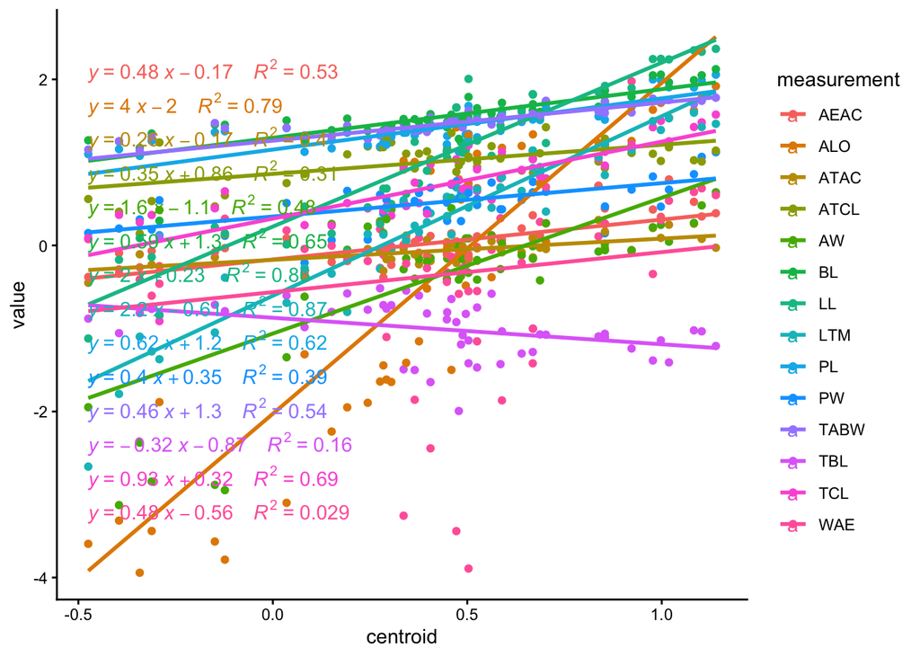

```r
df_lmw <- drop_na(df_lmw)
df_lmw$centroid <- log(df_iso$centroid)
df_long <- df_lmw %>% pivot_longer(
    cols = "TBL":"TABW",           # The range of columns you want to collapse
    names_to = "measurement",   # What to call the new column for the headers (TBL, PW, etc.)
    values_to = "value"         # What to call the new column for the numbers
  )

measurement <- c("BL","TABW")
p1 <-  df_long %>%# Only keeps these three
  ggplot(aes(x = centroid, y = value, color = measurement)) +
  geom_point() +
  geom_smooth(method = "lm", se=FALSE) +
  theme_classic() + stat_regline_equation(aes(label =  paste(..eq.label.., ..rr.label.., sep = "~~~~")))

p1
```

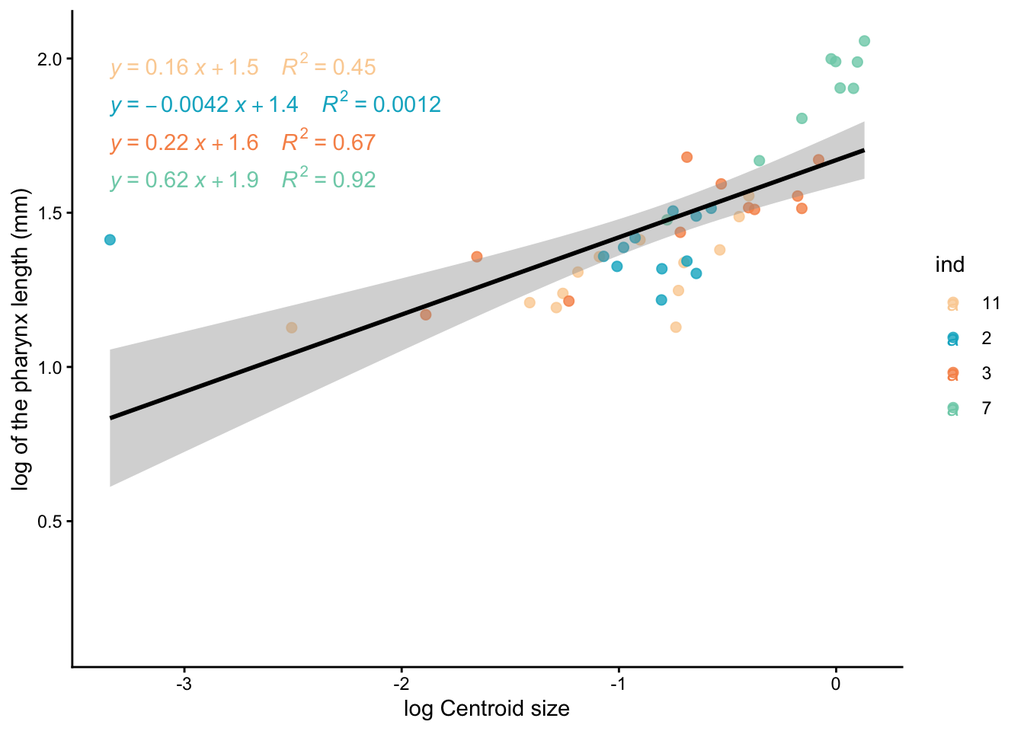

```r
p1 <-ggplot(df_lmw, aes(x = log(centroid), y = PL, color = ind)) +
    geom_point(size = 2, alpha = 0.8) +
    # Add the dashed regression line
    geom_smooth(method = "lm", formula = y ~ x, color = "black") +
    theme_classic() +
    labs(x = "log Centroid size", y = "log of the pharynx length (mm)") +
    scale_color_manual(values = c("#FBD1A2", "#00B2CA", "#F79256", "#7DCFB6")) +
    theme(legend.position = "right")+ stat_regline_equation(aes(label =  paste(..eq.label.., ..rr.label.., sep = "~~~~")))
p4 <-ggplot(df_lmw, aes(x = log(centroid), y = TABW, color = ind)) +
    geom_point(size = 2, alpha = 0.8) +
    # Add the dashed regression line
    geom_smooth(method = "lm", formula = y ~ x, color = "black") +
    theme_classic() +
    labs(x = "log Centroid size", y = "log of the body width (mm)") +
    scale_color_manual(values = c("#FBD1A2", "#00B2CA", "#F79256", "#7DCFB6")) +
    theme(legend.position = "right")+ stat_regline_equation(aes(label =  paste(..eq.label.., ..rr.label.., sep = "~~~~")))
p2 <- ggplot(df_lmw, aes(x = log(centroid), y = LL, color = ind)) +
    geom_point(size = 2, alpha = 0.8) +
    # Add the dashed regression line
    geom_smooth(method = "lm", formula = y ~ x, color = "black") +
    theme_classic() +
    labs(x = "log Centroid size", y = "log of the lobe Width (mm)") +
    scale_color_manual(values = c("#FBD1A2", "#00B2CA", "#F79256", "#7DCFB6")) +
    theme(legend.position = "right")+ stat_regline_equation(aes(label =  paste(..eq.label.., ..rr.label.., sep = "~~~~")))
p3 <- ggplot(df_lmw, aes(x = log(centroid), y = ALO, color = ind)) +
    geom_point(size = 2, alpha = 0.8) +
    # Add the dashed regression line
    geom_smooth(method = "lm", formula = y ~ x, color = "black") +
    theme_classic() +
    labs(x = "log Centroid size", y = "log of the auricle Length (mm)") +
    scale_color_manual(values = c("#FBD1A2", "#00B2CA", "#F79256", "#7DCFB6")) +
    theme(legend.position = "right")+ stat_regline_equation(aes(label =  paste(..eq.label.., ..rr.label.., sep = "~~~~")))

p1
```

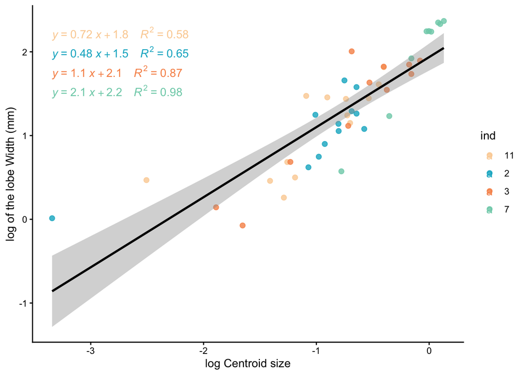

```r
p2
```

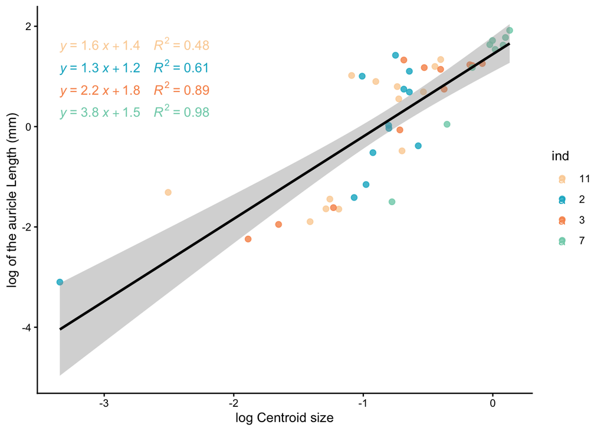

```r
p3
```

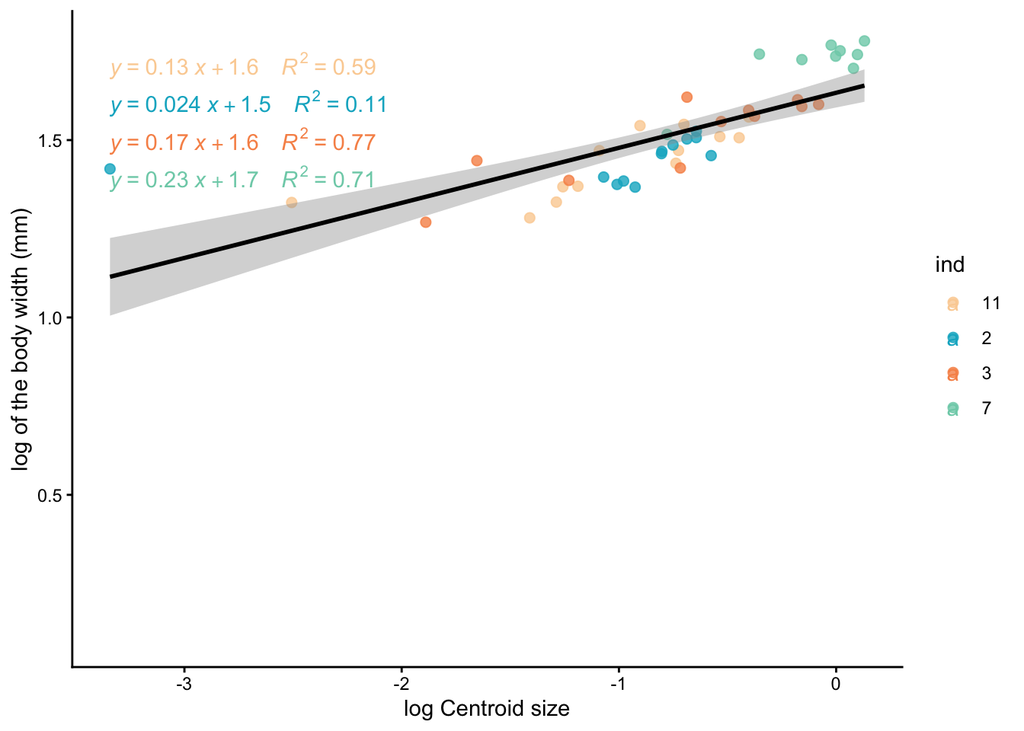

```r
p4
```

```r
p <- ggarrange(p1,p4, p2,p3, nrow = 2, ncol = 2)
```

```r
ggsave(file="/Volumes/Yinghui/202512-dev-seq-analyses/fig/p.svg", plot=p)
```

#### With all variables:

```r
df_LA <- df_lmw[,5:18]

measure_cols <- colnames(df_LA)

df_iso <- df_lmw %>%
  ungroup() %>%
  mutate(centroid = rowMeans(select(., TBL:TABW), na.rm = TRUE)) %>%
  ungroup() %>%
  mutate(across(all_of(measure_cols),
                ~ .x - centroid,
                .names = "shape_{.col}"))
```

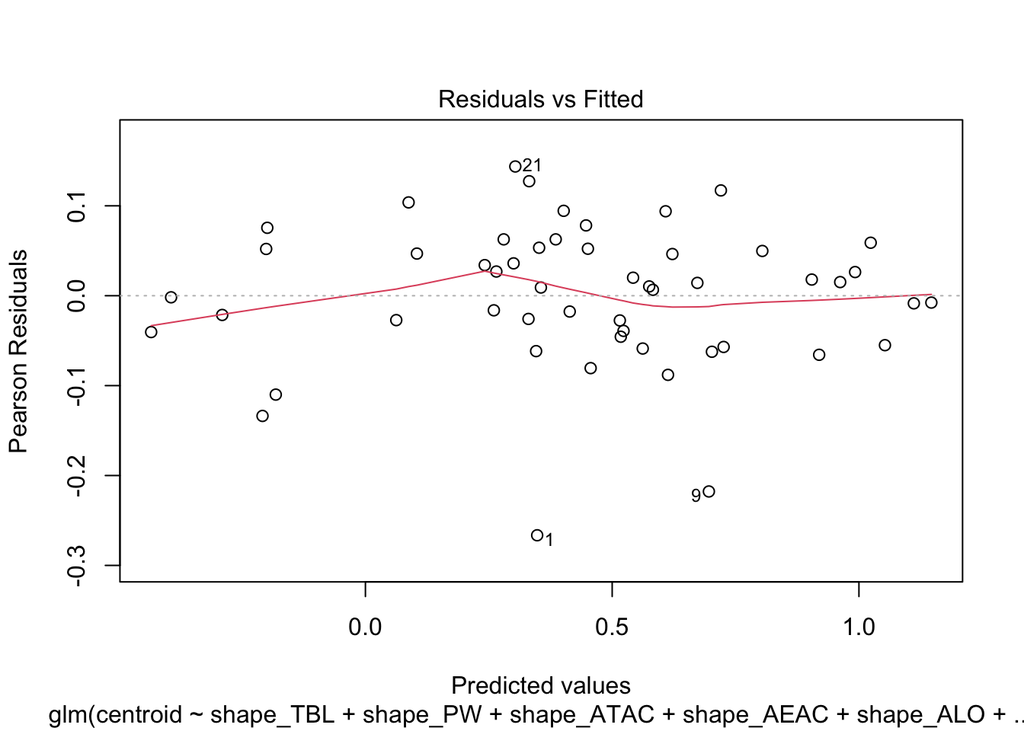

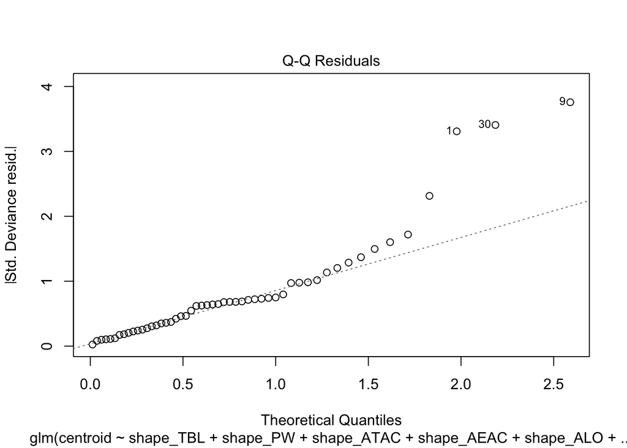

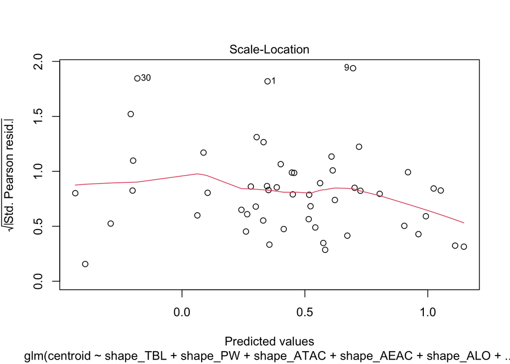

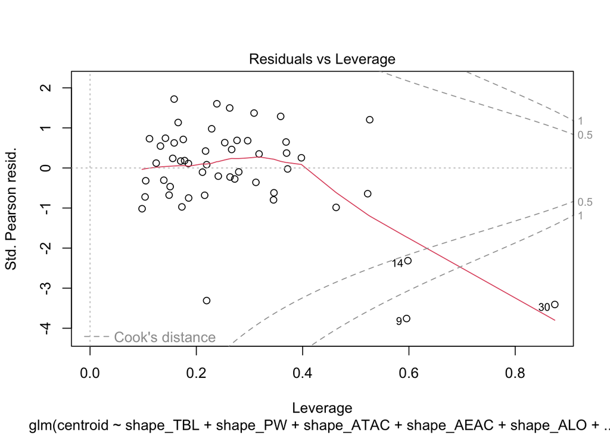

```r
model_LA = glm(formula = centroid ~ shape_TBL + shape_PW + shape_ATAC +shape_AEAC + shape_ALO+ shape_AW+ shape_WAE + shape_ATCL + shape_PL+ shape_BL+ shape_TCL + shape_LTM + shape_LL + shape_TABW, data = df_iso)
plot(model_LA)
```

```r
summary(model_LA)
```

```
##
## Call:
## glm(formula = centroid ~ shape_TBL + shape_PW + shape_ATAC +
##     shape_AEAC + shape_ALO + shape_AW + shape_WAE + shape_ATCL +
##     shape_PL + shape_BL + shape_TCL + shape_LTM + shape_LL +
##     shape_TABW, data = df_iso)
##
## Coefficients: (1 not defined because of singularities)
##              Estimate Std. Error t value Pr(>|t|)
## (Intercept)  0.659755   0.262067   2.518   0.0162 *
## shape_TBL    0.044546   0.211327   0.211   0.8342
## shape_PW    -0.001078   0.203269  -0.005   0.9958
## shape_ATAC  -0.346260   0.227407  -1.523   0.1361
## shape_AEAC   0.168778   0.227205   0.743   0.4621
## shape_ALO    0.136797   0.193730   0.706   0.4844
## shape_AW     0.187268   0.174140   1.075   0.2890
## shape_WAE    0.116106   0.194824   0.596   0.5547
## shape_ATCL  -0.374174   0.270803  -1.382   0.1751
## shape_PL     1.093750   0.374934   2.917   0.0059 **
## shape_BL    -0.592952   0.699676  -0.847   0.4020
## shape_TCL   -0.121464   0.252170  -0.482   0.6328
## shape_LTM    0.336845   0.228611   1.473   0.1489
## shape_LL    -0.092058   0.241413  -0.381   0.7051
## shape_TABW         NA         NA      NA       NA
## ---
## Signif. codes:  0 '***' 0.001 '**' 0.01 '*' 0.05 '.' 0.1 ' ' 1
##
## (Dispersion parameter for gaussian family taken to be 0.008304622)
##
##     Null deviance: 7.88452  on 51  degrees of freedom
## Residual deviance: 0.31558  on 38  degrees of freedom
## AIC: -87.87
##
## Number of Fisher Scoring iterations: 2
```

to assess the effect of allometry on shape variation:

For LMM, we regressed the linear data against the natural logarithm of the geometric mean with the lm.rrpp function of the “RRPP” package (version 1.3.1) (Collyer & Adams, 2018). We considered both centroid size and geometric mean as proxies for size in the context of geometric and LMM. (Viacava 2023)

## Clustering

### GMM analysis

Select variables that are most significant to the model

First we look at the result obtained using the function Mclust from the mclust package, with the best model selected by BIC for clustering on all the variables, allowing all possible parameterizations and the number of groups

```r
# pivot wide the data, so that each measurement is in a separate column
df_lmw <- df_lm %>%
  select(-c(plane, value)) %>%
  group_by(sample_id, ind) %>%
  pivot_wider(
    names_from = measure_name,
    values_from = log_value
  )
```

#### With all variables:

```r
df_LA <- df_lmw[,5:18]
df_LA <- drop_na(df_LA)
mod1 <- Mclust(df_LA,G=1:8)
summary(mod1)
```

```
## ----------------------------------------------------
## Gaussian finite mixture model fitted by EM algorithm
## ----------------------------------------------------
##
## Mclust EEE (ellipsoidal, equal volume, shape and orientation) model with 5
## components:
##
##  log-likelihood  n  df      BIC       ICL
##        333.6914 52 179 -39.8898 -39.91475
##
## Clustering table:
##  1  2  3  4  5
##  7 14 19  1 11
```

```r
out1 <- clustvarsel(df_LA, G=4)
out1
```

```
## ------------------------------------------------------
## Variable selection for Gaussian model-based clustering
## Stepwise (forward/backward) greedy search
## ------------------------------------------------------
##
##  Variable proposed Type of step   BICclust Model G   BICdiff Decision
##                 AW          Add -107.25150     E 4 39.006573 Accepted
##                ALO          Add -205.12341   VEV 4 90.257680 Accepted
##               TABW          Add -149.09398   VEV 4 47.106017 Accepted
##               TABW       Remove -205.12341   VEV 4 47.106017 Rejected
##                 PL          Add  -58.70138   EVV 4 31.237885 Accepted
##                 PL       Remove -149.09398   VEV 4 31.237885 Rejected
##                 LL          Add  -45.28302   VEV 4  5.967412 Accepted
##                 LL       Remove  -58.70138   EVV 4  5.967412 Rejected
##                LTM          Add  -51.32458   VEV 4 -8.919734 Rejected
##                 LL       Remove  -58.70138   EVV 4  5.967412 Rejected
##
## Selected subset: AW, ALO, TABW, PL, LL
```

[figure not shown]

```r
steps_data <- as.data.frame(out1$steps.info) %>%
  mutate(
    Step = row_number(),
    # 'Variable' is usually the name of the column added/removed
    Variable = rownames(out1$steps.info)
  ) %>%
  # We want to see how much the BIC improved at each step
  rename(BIC_Change = 1)

ggplot(steps_data, aes(x = reorder(Variable, Step), y = BIC_Change)) +
  geom_segment(aes(xend = Variable, yend = 0), color = "skyblue") +
  geom_point(aes(color = BIC_Change > 0), size = 4) +
  coord_flip() +  # Flip it to read variable names easily
  theme_minimal() +
  scale_color_manual(values = c("red", "darkgreen"), labels = c("Rejection", "Selection")) +
  labs(
    title = "Clustvarsel: Variable Importance",
    subtitle = "Variables ordered by their contribution to cluster separation",
    x = "Measurement Variable",
    y = "BIC Difference (Evidence Strength)",
    color = "Decision"
  )
```

```r
mod1_2 <-Mclust(df_LA[, out1$subset])
summary(mod1_2)
```

```
## ----------------------------------------------------
## Gaussian finite mixture model fitted by EM algorithm
## ----------------------------------------------------
##
## Mclust VEV (ellipsoidal, equal shape) model with 4 components:
##
##  log-likelihood  n df       BIC      ICL
##        117.6276 52 71 -45.28302 -45.5236
##
## Clustering table:
##  1  2  3  4
## 18 20  8  6
```

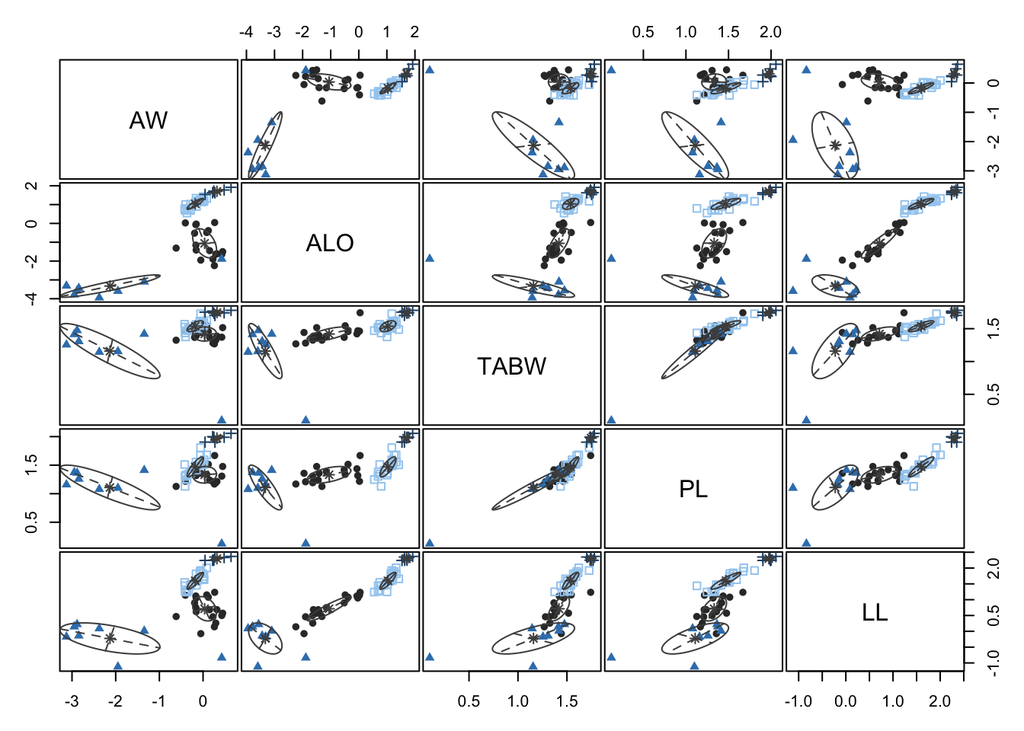

```r
#fviz_mclust(mod1_2,"classification",  geom = "point", palette = palette1)
plot(mod1_2, what = "classification", colors = palette1)
```

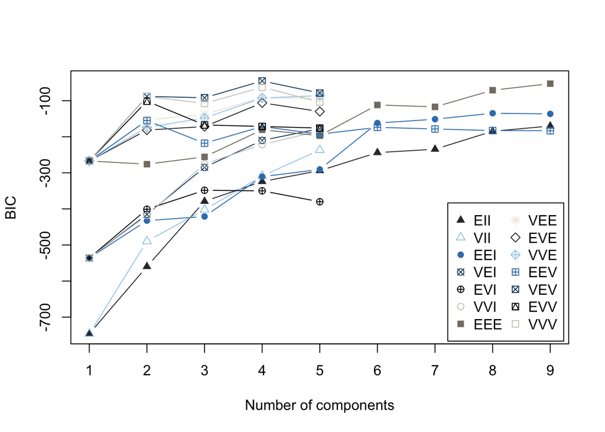

```r
plot(mod1_2, what = "BIC", colors = palette1)
```

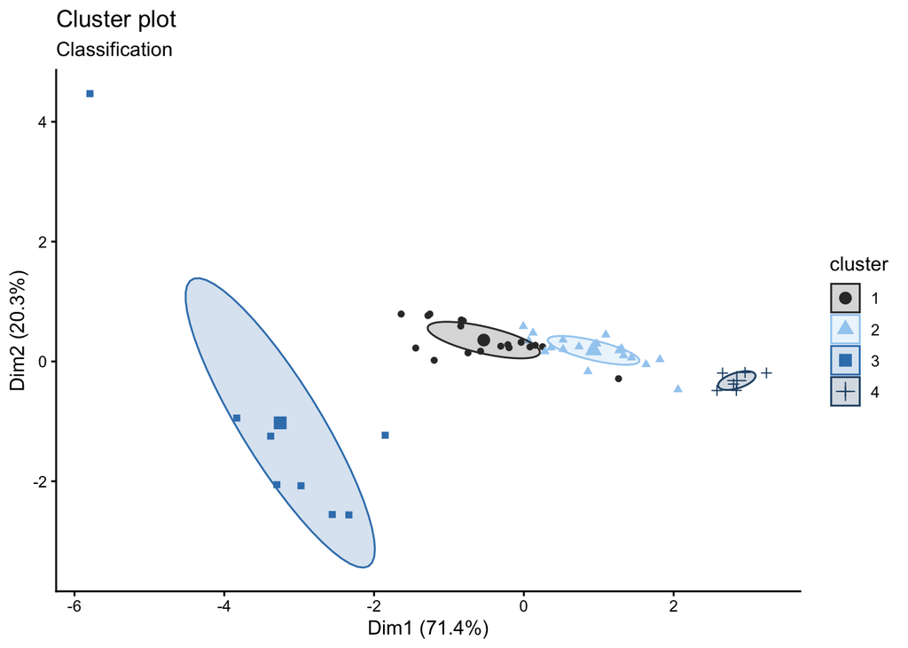

```r
#palette1 <- sample(palette1)
p1 <- fviz_mclust(mod1_2,"classification",  geom = "point", palette = palette1)
p1
```

```r
svglite("/Volumes/Yinghui/202512-dev-seq-analyses/fig/class1-bic.svg", width = 10, height = 10)

plot(mod1_2, what = "BIC", colors = palette1)
dev.off()
```

```r
ggsave(file="/Volumes/Yinghui/202512-dev-seq-analyses/fig/GMM1.svg", plot=p1, width=5, height=5)
```

```r
df_lmw_class <- drop_na(df_lmw)
df_lmw_class$classification <- as.factor(mod1_2$classification)


PCA2 <- prcomp(df_lmw_class[,5:18], scale. = FALSE)
summary(PCA2)
```

```
## Importance of components:
##                           PC1    PC2     PC3     PC4     PC5     PC6     PC7
## Standard deviation     2.2751 1.1144 0.76434 0.45908 0.30043 0.21329 0.18598
## Proportion of Variance 0.6949 0.1667 0.07843 0.02829 0.01212 0.00611 0.00464
## Cumulative Proportion  0.6949 0.8617 0.94009 0.96838 0.98050 0.98661 0.99125
##                           PC8     PC9    PC10    PC11    PC12    PC13    PC14
## Standard deviation     0.1726 0.12736 0.07980 0.07425 0.06424 0.05330 0.01765
## Proportion of Variance 0.0040 0.00218 0.00086 0.00074 0.00055 0.00038 0.00004
## Cumulative Proportion  0.9952 0.99743 0.99828 0.99902 0.99958 0.99996 1.00000
```

```r
p <- fviz_pca_ind(PCA2, geom.ind = "point",
             col.ind = df_lmw_class$classification, # color by groups
             palette = c("#94A29C", "#8DB2B9", "#384F57","#546A7B"),
             addEllipses = TRUE, ellipse.type = "convex",
             legend.title = "Groups")

ggsave(file="/Volumes/Yinghui/202512-dev-seq-analyses/fig/PCA1.svg", plot=p, width=5, height=5)
```

```
## Ignoring unknown labels:
## • linetype : "Groups"
```

##### with iso (shape only)

```r
mod1_1 <- Mclust(df_iso[,19:33])
summary(mod1_1)
```

```
## ----------------------------------------------------
## Gaussian finite mixture model fitted by EM algorithm
## ----------------------------------------------------
##
## Mclust XXX (ellipsoidal multivariate normal) model with 1 component:
##
##  log-likelihood  n  df      BIC      ICL
##        2029.086 52 135 3524.755 3524.755
##
## Clustering table:
##  1
## 52
```

#### With no auricle and lobe related measurements:

```r
df_noLA <- df_lmw[,!names(df_lmw) %in% c("ALO", "AW", "LL", "LTM", "sample_id", "temp", "ind", "biorep")]

#examine their correlation
m <- cor(df_noLA)
# Convert matrix to data frame and reshape
cor_df <- as.data.frame(m)

a <- which(cor_df>0.99, arr.ind=T)
row.names(cor_df[a[,1],] )
```

```
##  [1] "TBL"    "PW"     "ATAC"   "AEAC"   "WAE"    "ATCL"   "PL"     "BL"
##  [9] "TABW"   "PL.1"   "BL.1"   "TABW.1" "TCL"    "PL.2"   "BL.2"   "TABW.2"
```

```r
names(cor_df[a[,2]])
```

```
##  [1] "TBL"    "PW"     "ATAC"   "AEAC"   "WAE"    "ATCL"   "PL"     "PL.1"
##  [9] "PL.2"   "BL"     "BL.1"   "BL.2"   "TCL"    "TABW"   "TABW.1" "TABW.2"
```

```r
mod2 <- Mclust(df_noLA)
summary(mod2)
```

```
## ----------------------------------------------------
## Gaussian finite mixture model fitted by EM algorithm
## ----------------------------------------------------
##
## Mclust VEV (ellipsoidal, equal shape) model with 3 components:
##
##  log-likelihood  n  df       BIC       ICL
##        314.5691 82 179 -159.6646 -160.3657
##
## Clustering table:
##  1  2  3
## 20 31 31
```

Selecting variable useful for clustering

```r
out2 <- clustvarsel(df_noLA)
out2
```

```
## ------------------------------------------------------
## Variable selection for Gaussian model-based clustering
## Stepwise (forward/backward) greedy search
## ------------------------------------------------------
##
##  Variable proposed Type of step  BICclust Model G    BICdiff Decision
##               ATAC          Add -174.6809     V 2 134.203392 Accepted
##               ATCL          Add -193.2466   VVE 4  58.872650 Accepted
##               TABW          Add -154.9725   VVV 3  25.131157 Accepted
##               TABW       Remove -193.2466   VVE 4  25.131157 Rejected
##                TCL          Add -137.9379   VEV 3  30.617997 Accepted
##                TCL       Remove -154.9725   VVV 3  30.617997 Rejected
##                TBL          Add -188.6163   VEV 3  -6.334393 Rejected
##                TCL       Remove -154.9725   VVV 3  30.617997 Rejected
##
## Selected subset: ATAC, ATCL, TABW, TCL
```

Construct the clustering model again

```r
mod2_2 <-Mclust(df_noLA[, out2$subset])
summary(mod2_2)
```

```
## ----------------------------------------------------
## Gaussian finite mixture model fitted by EM algorithm
## ----------------------------------------------------
##
## Mclust VEV (ellipsoidal, equal shape) model with 3 components:
##
##  log-likelihood  n df       BIC       ICL
##        14.75872 82 38 -137.9379 -140.6011
##
## Clustering table:
##  1  2  3
## 20 21 41
```

```r
palette1 <- sample(palette1)
p3 <- fviz_mclust(mod2_2,"classification",  geom = "point", palette = palette1)

svglite("/Volumes/Yinghui/202512-dev-seq-analyses/fig/class2.svg", width = 10, height = 10)
plot(mod2_2, what = "classification", colors = palette1)
dev.off()
```

```r
ggsave(file="/Volumes/Yinghui/202512-dev-seq-analyses/fig/GMM2.svg", plot=p3, width=10, height=10)
```

### K-means

for group w.o lobe or auricle

```r
km.res <- kmeans(df_noLA,5)
print(km.res)
```

```
## K-means clustering with 5 clusters of sizes 6, 4, 21, 42, 9
##
## Cluster means:
##          TBL         PW        ATAC        AEAC        WAE      ATCL         PL
## 1 -1.7588757 -1.0967475 -2.31465964 -2.01928357 -2.7834666 -1.448598 -0.4151363
## 2 -2.5034847 -2.1611274 -3.71613294 -3.60048361 -2.5588898 -2.122326 -0.9050358
## 3 -1.1002956  0.2521189 -0.43722249 -0.26402567 -1.4049488  0.478412  1.0821218
## 4 -0.9618024  0.5028010 -0.06177967  0.03862772  0.1067422  1.005088  1.4423482
## 5 -2.7541873 -2.4211679 -4.21983426 -4.01872020 -4.3042550 -2.476870 -1.4708263
##           BL        TCL       TABW
## 1 -0.2320550 -1.7164547 -0.1435711
## 2 -0.6609503 -2.0889250 -0.7536314
## 3  1.2200840  0.2518222  1.1184239
## 4  1.5652279  0.7002688  1.4756300
## 5 -1.1646499 -2.6545552 -1.1426004
##
## Clustering vector:
##  [1] 5 5 5 3 3 4 4 4 4 4 4 4 4 4 4 3 3 4 4 5 5 2 1 3 3 4 3 3 4 4 4 4 4 4 4 4 4 3
## [39] 3 3 5 5 5 2 1 1 3 3 4 4 4 3 3 4 4 3 4 4 3 4 3 5 2 2 1 1 1 3 3 4 3 4 4 4 4 4
## [77] 4 4 4 4 4 4
##
## Within cluster sum of squares by cluster:
## [1]  6.586983  8.572156 62.208515 43.112715  8.750927
##  (between_SS / total_SS =  89.7 %)
##
## Available components:
##
## [1] "cluster"      "centers"      "totss"        "withinss"     "tot.withinss"
## [6] "betweenss"    "size"         "iter"         "ifault"
```

### PCA

```r
PCA2 <- prcomp(select_if(df_noLA, is.numeric), scale. = FALSE)
summary(PCA2)
```

```
## Importance of components:
##                           PC1     PC2    PC3     PC4     PC5     PC6     PC7
## Standard deviation     3.7624 0.95475 0.4814 0.33012 0.26214 0.19236 0.13155
## Proportion of Variance 0.9101 0.05861 0.0149 0.00701 0.00442 0.00238 0.00111
## Cumulative Proportion  0.9101 0.96872 0.9836 0.99062 0.99504 0.99742 0.99853
##                            PC8     PC9    PC10
## Standard deviation     0.12703 0.07822 0.02479
## Proportion of Variance 0.00104 0.00039 0.00004
## Cumulative Proportion  0.99957 0.99996 1.00000
```

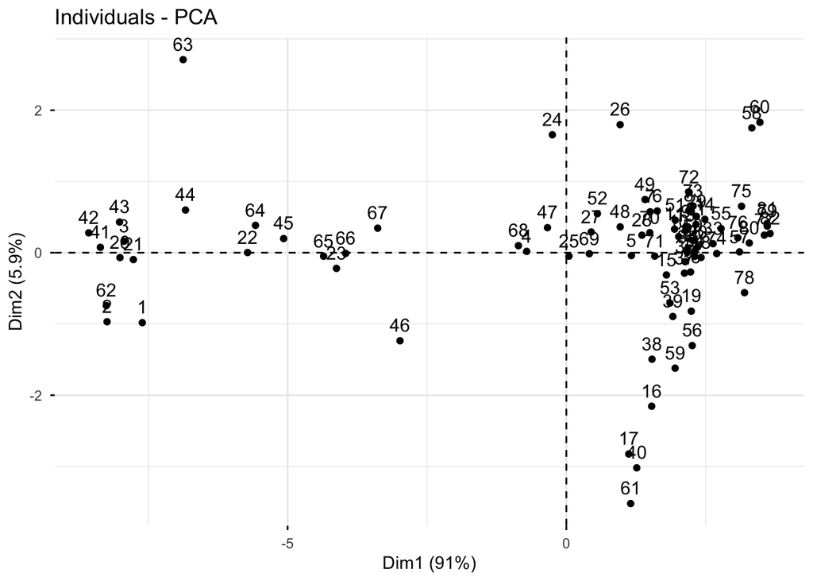

```r
fviz_pca_ind(PCA2)
```

```r
df_lmw
```

```
## # A tibble: 82 × 18
## # Groups:   sample_id, ind [82]
##    sample_id ind   temp  biorep         TBL      PW    ATAC    AEAC   ALO     AW
##    <chr>     <chr> <chr> <chr>        <dbl>   <dbl>   <dbl>   <dbl> <dbl>  <dbl>
##  1 0905      11    20    202509-dev… -2.78  -2.16   -3.86   -3.48   NA    NA
##  2 0907      11    20    202509-dev… -2.63  -2.23   -3.87   -3.52   NA    NA
##  3 0909      11    20    202509-dev… -3.16  -2.65   -3.80   -3.48   NA    NA
##  4 0915      11    20    202509-dev… -1.05  -0.519  -1.03   -0.868  NA    NA
##  5 0917      11    20    202509-dev… -0.814  0.231  -0.209  -0.299  NA    NA
##  6 0919      11    20    202509-dev… -0.880  0.212  -0.256  -0.275  NA    NA
##  7 0921      11    20    202509-dev… -0.984 -0.210  -0.388  -0.322  -1.31 -0.616
##  8 0923      11    20    202509-dev… -0.516  0.612  -0.0744 -0.271  -1.64  0.291
##  9 0925      11    20    202509-dev… -0.719  0.439  -0.169  -0.234  -1.64  0.429
## 10 0927      11    20    202509-dev… -0.774  0.0698 -0.0436 -0.0818 -1.90  0.227
## # ℹ 72 more rows
## # ℹ 8 more variables: WAE <dbl>, ATCL <dbl>, PL <dbl>, BL <dbl>, TCL <dbl>,
## #   LTM <dbl>, LL <dbl>, TABW <dbl>
```